# Predict Number of Future Elk Hunters per Unit Season

Pierre Sarnow

## Description

Use historical draw results, and number of hunters to train a model we can use to predict the number of hunters in future years. I would like to compare this to the results we generated by grouping the seasons together.

**NOTICE** that I am only looking at the general rifle hunting seasons on public land. There are also hunters for Archery, Muzzleloader, Private Land, Ranching for Wildlife, etc.

## Setup

Load required libraries for wrangling data, charting, and mapping

```r
library(plyr,quietly = T) # data wrangling
library(dplyr,quietly = T) # data wrangling
library(ggplot2, quietly = T) # charting
library(ggthemes,quietly = T) # so I can add the highcharts theme and palette
library(scales,quietly = T) # to load the percent function when labeling plots
library(caret,quietly = T) # classification and regression training
library(foreach,quietly = T) # parallel processing to speed up the model training
library(doMC,quietly = T) # parallel processing to speed up the model training
library(lubridate,quietly = T) # for timing models
```

Set our preferred charting theme

```r
theme_set(theme_minimal()+theme_hc()+theme(legend.key.width = unit(1.5, "cm")))
```

Run script to get hunter data

```r
source('~/_code/colorado-dow/datasets/Colorado Elk Harvest Data.R', echo=F)
```

```
Error in select(SuccessTables, -Harvest.Antlerless, -Hunters.Antlerless,  :
  unused arguments (-Harvest.Antlerless, -Hunters.Antlerless, -Success.Antlerless)
```

```r
head(COElkRifleAll)
```

Run script to get draw data

```r
source('~/_code/colorado-dow/datasets/Elk Drawing Summaries.R', echo=F)
```

```r
head(COElkDrawAll)
```

source geodata

```r
source('~/_code/colorado-dow/datasets/Colorado GMUnit and Road data.R', echo=F)
```

Take a peak at the boundary data

```r
head(Unitboundaries2)
```

Set to predictive analytics directory

```r
setwd("~/_code/colorado-dow/phase III - predictive analytics")
```

### Organize data

Will start by grouping all of the seasons together, and modeling the number of hunters per Year and Unit

Group Draw results data by Year and Unit

```r
COElkDraw_Unit <- summarise(group_by(COElkDrawAll,Year,Unit,Season),
                       Quota = sum(Orig_Quota,na.rm = T),
                       Drawn = sum(Chcs_Drawn,na.rm = T))
```

Appropriate field classes for model training

```r
COElkDraw_Unit$Year <- as.numeric(COElkDraw_Unit$Year)
```

Group Hunter data by Year and Unit

```r
COElkHunters_Unit <- summarise(group_by(COElkRifleAll,Year,Unit,Season),
                          Hunters = sum(c(Hunters.Antlered,Hunters.Antlerless,Hunters.Either),na.rm = T))
COElkHunters_Unit$Year <- as.numeric(COElkHunters_Unit$Year)
```

Join in Hunter and Draw data together

```r
COElkHunters_Unit <- left_join(COElkHunters_Unit, COElkDraw_Unit, by = c("Year","Unit","Season"))
```

Replace the draw data that don’t have entries with 0

```r
COElkHunters_Unit$Drawn[is.na(COElkHunters_Unit$Drawn)] <- 0
COElkHunters_Unit$Quota[is.na(COElkHunters_Unit$Quota)] <- 0
```

Split into train and test sets. Will use 75% of the data to train on.

```r
COElkHunters_Unit <- mutate(group_by(COElkHunters_Unit,Unit),
                       numentries = n())
COElkHunters_Unit <- filter(COElkHunters_Unit, numentries >= 3)
COElkHunters_Unit$UnitYearSeason <- paste(COElkHunters_Unit$Unit, COElkHunters_Unit$Year,COElkHunters_Unit$Season)
traindata2 <- COElkHunters_Unit %>% group_by(Unit) %>% sample_frac(size = .75, replace = F)
testdata2 <- COElkHunters_Unit[!COElkHunters_Unit$UnitYearSeason %in% traindata2$UnitYearSeason,]
COElkHunters_Unit <- select(COElkHunters_Unit, -UnitYearSeason, -numentries)
traindata2 <- select(traindata2, -UnitYearSeason, -numentries)
testdata2 <- select(testdata2, -UnitYearSeason, -numentries)
```

Save off for importing into AzureML

```r
write.csv(COElkHunters_Unit,file = "~/_code/colorado-dow/datasets/COElkHunters_Unit.csv",row.names = F)
```

### Data Visualization

notice that the number of hunters data is skewed.

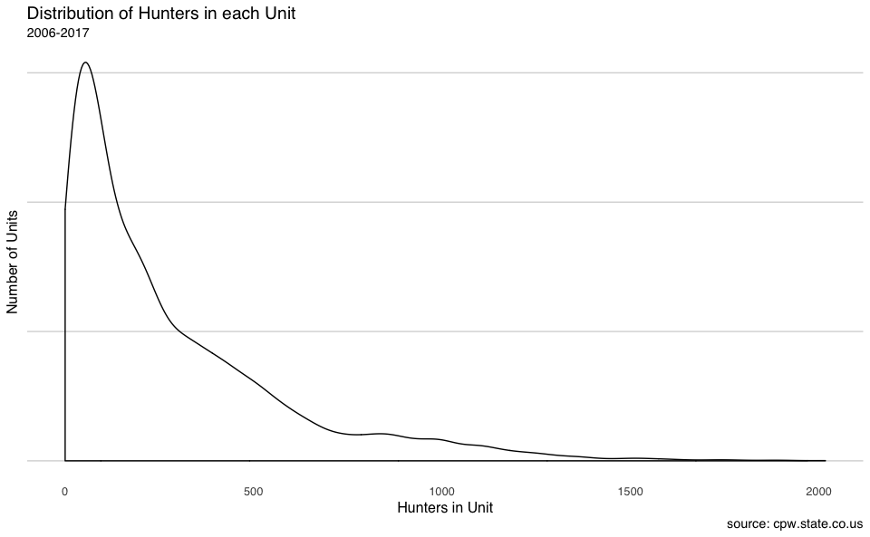

```r
ggplot(COElkHunters_Unit, aes(Hunters)) +
  geom_density() +
  xlab("Hunters in Unit") +
  ylab("Number of Units") +
  theme(axis.text.y = element_blank()) +
  labs(title="Distribution of Hunters in each Unit", subtitle="2006-2017", caption="source: cpw.state.co.us")
```

A general rule of thumb to consider is that skewed data whose ratio of the highest value to the lowest value is greater than 20 have significant skewness. Also, the skewness statistic can be used as a diagnostic. If the predictor distribution is roughly symmetric, the skewness values will be close to zero. As the distribution becomes more right skewed, the skewness statistic becomes larger. Similarly, as the distribution becomes more left skewed, the value becomes negative. Replacing the data with the log, square root, or inverse may help to remove the skew.

```r
preProcValues2 <- preProcess(as.data.frame(traindata2), method = "BoxCox")
trainBC <- predict(preProcValues2, as.data.frame(traindata2))
```

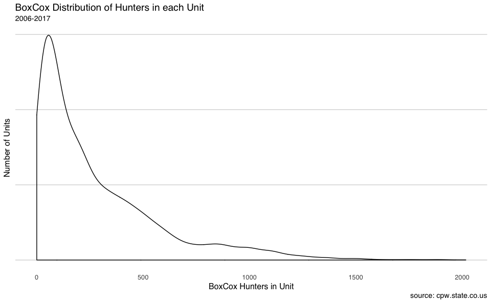

```r
ggplot(trainBC, aes(Hunters)) +
  geom_density() +
  xlab("BoxCox Hunters in Unit") +
  ylab("Number of Units") +
  theme(axis.text.y = element_blank()) +
  labs(title="BoxCox Distribution of Hunters in each Unit", subtitle="2006-2017", caption="source: cpw.state.co.us")
```

caret has a preproccess function for correcting for skewness ‘BoxCox’, we will need to be sure to look at using this function in the training models.

## Model Building

### Model Training Methods

```r
quickmethods <- c("lm",'svmLinear',"svmRadial","knn","cubist","kknn","glm.nb")
step1_all_Unit <- NULL
for (imethod in quickmethods) {
  step1_Unit <- NULL
  start <- now()

  # if (imethod == "lm") {
  #   controlmethod <- "repeatedcv"
  # } else {controlmethod <- "adaptive_cv"}
  controlmethod <- "repeatedcv"
  fitControl <- trainControl(
    method = controlmethod,
    # search = 'random',
    number = 4,
    repeats = 4,
    allowParallel = TRUE,
    summaryFunction = defaultSummary)

  registerDoSEQ()
  registerDoMC(cores = 6)

  HuntersModel_1_Unit = train(Hunters ~ ., data = traindata2,
                         method = imethod,
                         tuneLength = 15,
                         trControl = fitControl)

  HuntersModel_1_Unit

  # measure performance
  predictdata <- predict(HuntersModel_1_Unit, testdata2)

  step1_Unit$method <- imethod
  step1_Unit$RMSE <- postResample(pred = predictdata, obs = testdata2$Hunters)[1]
  step1_Unit$duration <- now() - start
  step1_Unit <- as.data.frame(step1_Unit)
  step1_all_Unit <- rbind(step1_all_Unit,step1_Unit)
}
```

[output not shown]

View Results, and compare to previous first models that did not expand to Seasons

```r
step1_all
```

```
         method     RMSE       duration
RMSE         lm 165.0025  6.866598 secs
RMSE1 svmLinear 178.0942  4.950974 secs
RMSE2 svmRadial 134.0561 22.081016 secs
RMSE3       knn 733.8210 10.502875 secs
RMSE4    cubist 151.9572  3.057477 secs
RMSE5      kknn 132.0211  9.778734 secs
RMSE6    cubist 160.5464  1.027274 secs
```

```r
step1_all_Unit
```

```
         method      RMSE       duration
RMSE         lm 153.24028  3.146424 secs
RMSE1 svmLinear 162.96937 31.758684 secs
RMSE2 svmRadial  60.62208  7.481067 secs
RMSE3       knn 224.88778  1.459118 secs
RMSE4    cubist  63.20635  2.664269 secs
RMSE5      kknn  57.59955  5.068010 secs
RMSE6    glm.nb 161.06055 18.607480 secs
```

Build model

```r
controlmethod <- "repeatedcv"
  fitControl <- trainControl(
    method = controlmethod,
    # search = 'random',
    number = 4,
    repeats = 4,
    allowParallel = TRUE,
    summaryFunction = defaultSummary)

registerDoSEQ()
registerDoMC(cores = 6)

HuntersModel_1_Unit = train(Hunters ~ ., data = COElkHunters_Unit,
                         method = "svmRadial",
                         # preProc = c("center","scale"),
                         tuneLength = 15,
                         trControl = fitControl)

HuntersModel_1_Unit
```

```
Support Vector Machines with Radial Basis Function Kernel

6022 samples
   5 predictor

No pre-processing
Resampling: Cross-Validated (4 fold, repeated 4 times)
Summary of sample sizes: 4516, 4515, 4518, 4517, 4517, 4516, ...
Resampling results across tuning parameters:

  C        RMSE       Rsquared   MAE
     0.25  165.11678  0.7321893  99.83178
     0.50  153.00322  0.7587465  92.55356
     1.00  137.94672  0.8001821  82.60569
     2.00  118.53390  0.8520248  70.15132
     4.00   98.10570  0.8977195  58.23606
     8.00   81.44651  0.9276793  50.10515
    16.00   72.00511  0.9416747  45.61673
    32.00   67.82607  0.9475692  43.21396
    64.00   65.01697  0.9516157  41.54591
   128.00   62.98457  0.9545102  40.12867
   256.00   61.85285  0.9560942  39.32768
   512.00   61.35372  0.9568002  38.92707
  1024.00   61.64766  0.9564220  38.99960
  2048.00   62.23304  0.9556303  39.26794
  4096.00   63.32468  0.9540772  39.62725

Tuning parameter 'sigma' was held constant at a value of 0.003719777
RMSE was used to select the optimal model using the smallest value.
The final values used for the model were sigma = 0.003719777 and C = 512.
```

Predict Hunter for next year, 2018

```r
# Get list of Units and Seasons that will have data
COElkHunters2018_Unit <- COElkHunters_Unit
COElkHunters2018_Unit$Unit_Season <- paste(COElkHunters2018_Unit$Unit,COElkHunters2018_Unit$Season)
COElkHunters2018_Unit <- as.data.frame(unique(COElkHunters2018_Unit$Unit_Season))
colnames(COElkHunters2018_Unit) <- "Unit_Season"
# Fill in missing Units and Seasons per unique Unit_Seasons
COElkHunters2018_Unit$Unit <- str_extract(COElkHunters2018_Unit$Unit_Season,"[:alnum:]+(?=[:blank:])")
COElkHunters2018_Unit$Season <- str_extract(COElkHunters2018_Unit$Unit_Season,"(?<=[:blank:])[:alnum:]+")
COElkHunters2018_Unit <- select(COElkHunters2018_Unit, -Unit_Season)
COElkHunters2018_Unit$Year <- 2018
# Draw data for 2018
COElkDraw_Unit2018 <- filter(COElkDraw_Unit,Year==2018)
# A left join will autofill missing draw data with NAs, but will retain the full list of Unit Seasons
COElkHunters2018_Unit <- left_join(COElkHunters2018_Unit,COElkDraw_Unit2018)
# Replace the draw data that don't have entries with 0
COElkHunters2018_Unit$Drawn[is.na(COElkHunters2018_Unit$Drawn)] <- 0
COElkHunters2018_Unit$Quota[is.na(COElkHunters2018_Unit$Quota)] <- 0
# Only use the fields that were included in the model
COElkHunters2018_Unit <- COElkHunters2018_Unit[, colnames(COElkHunters2018_Unit) %in% c("Unit","Season",HuntersModel_1_Unit$coefnames)]
# Use trained model to predict Hunters
COElkHunters2018_Unit$Hunters <- round(predict(HuntersModel_1_Unit, COElkHunters2018_Unit))
COElkHunters2018_Unit$Hunters[COElkHunters2018_Unit$Hunters<0] <- 0
```

Label and Join models together for comparisons

```r
# Load first model without Seasons
load("~/_code/colorado-dow/datasets/COElkHunters2018.RData")
Hunterscompare <- rbind.fill(COElkHunters,COElkHunters2018)
Hunterscompare$modeldata <- "Without Seasons"
Hunterscompare_Season <- rbind.fill(COElkHunters_Unit,COElkHunters2018_Unit)
Hunterscompare_Season <- summarise(group_by(Hunterscompare_Season,Year,Unit),
                                   Hunters = sum(Hunters))
Hunterscompare_Season$modeldata <- "Seasons"
Hunterscompare <- rbind.fill(Hunterscompare,Hunterscompare_Season)
```

```r
# Group Units
HunterscompareStatewide <- summarise(group_by(Hunterscompare,Year,modeldata),
                                   Hunters = sum(Hunters))
```

```r
ggplot(HunterscompareStatewide, aes(Year,Hunters,group=modeldata,fill=modeldata)) +
  geom_bar(position="dodge",stat="identity") +
  coord_cartesian(ylim = c(130000,155000)) +
  scale_fill_hc() +
  labs(title="Statewide Elk Hunters", caption="source: cpw.state.co.us")
```

[output not shown]

#### Hunters Statewide by Season and Year

```r
Hunters_Season <- rbind.fill(COElkHunters_Unit,COElkHunters2018_Unit)
ggplot(Hunters_Season, aes(Year,Hunters,group=Season,fill=Season)) +
  geom_bar(position="dodge",stat="identity") +
  # coord_cartesian(ylim = c(130000,155000)) +
  scale_fill_hc() +
  labs(title="Statewide Elk Hunters", caption="source: cpw.state.co.us")
```

[output not shown]

#### Hunters in Unit 77

```r
Hunters_Season_77 <- filter(Hunters_Season, Unit == "77")
ggplot(Hunters_Season_77, aes(Year,Hunters,group=Season,fill=Season)) +
  geom_bar(position="dodge",stat="identity") +
  # coord_cartesian(ylim = c(130000,155000)) +
  scale_fill_hc() +
  labs(title="Unit 77 Elk Hunters", caption="source: cpw.state.co.us")
```

[output not shown]

### Compare to the Draw Data (Quota, Drawn)

[figure not shown]

```r
Data_Season_77 <- gather(Hunters_Season_77,"Field",Amount,Hunters,Quota,Drawn)
ggplot(Data_Season_77, aes(Season,Amount,fill=Field,group=Field)) +
  # geom_point() +
  # geom_line() +
  facet_grid(. ~ Year) +
  geom_bar(position="dodge",stat="identity") +
  # coord_cartesian(ylim = c(130000,155000)) +
  scale_fill_hc() +
  labs(title="Statewide Elk Hunters", caption="source: cpw.state.co.us")
```

[figure not shown]

```r
ggplot(Data_Season_77, aes(Year,Amount,color=Field,group=Field)) +
  # geom_point() +
  geom_line() +
  facet_grid(Season ~ .,scales = 'free') +
  # geom_bar(position="dodge",stat="identity") +
  # coord_cartesian(ylim = c(130000,155000)) +
  scale_color_hc() +
  labs(title="Statewide Elk Hunters", caption="source: cpw.state.co.us")
```

## Keep going by creating models for hunters per year, unit and season?

I believe the results appear reasonable.

We can further identify better models and tune them. But right now we will proceed with the last trained model…. revisiting after the project is more complete.

Save off so we don’t have to recreate the model everytime we want the results

```r
FinalHuntersSeasonmodel <- HuntersModel_1_Unit
```

```r
save(FinalHuntersSeasonmodel, file = "~/_code/colorado-dow/datasets/FinalHuntersSeasonmodel.RData")
```

```r
COElkHunters2018_Season <- COElkHunters2018_Unit
save(COElkHunters2018_Season,file="~/_code/colorado-dow/datasets/COElkHunters2018_Season.RData")
```